# Relationship between Personality and Film-watching Patterns based on MBTI

Project 2

SID1:540409697 SID2:540287718 SID3:540237207 SID4:530000648 SID5:540342888 SID6:540354973

University of Sydney | DATA1001 | 14/04/2024

# 1 Executive Summary

- The aim of the survey is not only to discover the relationship between 16 personalities based on MBTI and film-watching patterns but also to break the stereotype in people’s minds.

# 2 Full Report

## 2.1 Initial Data Analysis (IDA)

### 2.1.1 Source

The data was collected from university students from 6/3/24-8/4/24, using Google Forms (https://docs.google.com/forms/d/e/1FAIpQLSdWSzdFI19hBPrcVea9mrK0f8h0NBiMFSDsM6z3Vr_LTRt0EQ/viewform?usp=sf_link)

### 2.1.2 Structure

The survey received 119 responses, represented by rows. Variables were represented by columns, including qualitative (MBTI, Gender, Type1, Type2, Pattern, Period, Place), and quantitative variables (Row, Times/month, people). Using the `read_csv` command, columns were classified whilst importing data.

### 2.1.3 Limitations

- MBTI relies on self-reported responses to a series of questions. This can result in data that is influenced by the subjectivity of the participant.
- Selection bias - Over 2/3 of the respondents are Chinese.
- The sample diversity is insufficient, the number of collected personality types is uneven, and no samples of ESFJ were collected.
- The survey questions and analytical perspectives are relatively narrow, with many binary options for the questions, and the analytical approach is also based on a dichotomous view of personality.

### 2.1.4 Assumptions

Some unrealistic responses (i.e. Sitting in row 5.1) are not appropriate.

### 2.1.5 Data Clearing

Absurd responses (i.e. a university student prefer to sit in the 5.1 row of the Cinema) were excluded using `filter()`. Summaries based on personality types were created to give an intuitionistic view.

```r
library(tidyverse)
library(RColorBrewer)
library(stringr)

mbti <- read.csv("C:/Users/24022/Desktop/DATA1001/Group Work/mbti.csv")
subset_mbti <- subset(mbti, grepl("^[1-9][0-9]*$", Row))

e_count <- subset_mbti %>% filter(str_detect(MBTI, "E")) %>% summarize(Count = n()) %>% mutate(Type = "E")
i_count <- subset_mbti %>% filter(str_detect(MBTI, "I")) %>% summarize(Count = n()) %>% mutate(Type = "I")
n_count <- subset_mbti %>% filter(str_detect(MBTI, "N")) %>% summarize(Count = n()) %>% mutate(Type = "N")
s_count <- subset_mbti %>% filter(str_detect(MBTI, "S")) %>% summarize(Count = n()) %>% mutate(Type = "S")
t_count <- subset_mbti %>% filter(str_detect(MBTI, "T")) %>% summarize(Count = n()) %>% mutate(Type = "T")
f_count <- subset_mbti %>% filter(str_detect(MBTI, "F")) %>% summarize(Count = n()) %>% mutate(Type = "F")
j_count <- subset_mbti %>% filter(str_detect(MBTI, "J")) %>% summarize(Count = n()) %>% mutate(Type = "J")
p_count <- subset_mbti %>% filter(str_detect(MBTI, "P")) %>% summarize(Count = n()) %>% mutate(Type = "P")

all_counts <- bind_rows(e_count, i_count, n_count, s_count, t_count, f_count, j_count, p_count)

print(all_counts)
```

```
##   Count Type
## 1    43    E
## 2    75    I
## 3    87    N
## 4    31    S
## 5    45    T
## 6    73    F
## 7    57    J
## 8    61    P
```

### 2.1.6 Research Theme

An Investigation into the Relationship Between Personality and Film-watching Patterns Based on MBTI

## 2.2 Research Question 1

what is the relationship between personalities and film-watching preferences?

**Film-watching Location**  
Proportion of Film-watching Locations

```r
table(mbti$Place)
```

```
##
## Cinema   Home
##     68     51
```

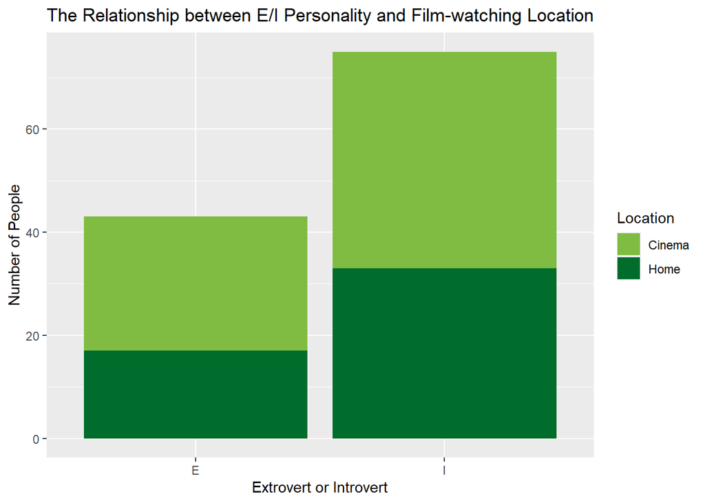

```r
mbti_cleaned <- subset_mbti %>%
 mutate(EI = ifelse(str_sub(MBTI, 1,1) %in% c("E", "I"), str_sub(MBTI, 1,1), NA))

ggplot(mbti_cleaned, aes(x = EI, fill = Place)) +
  geom_bar(stat = "count") +
  labs(x = "Extrovert or Introvert", y = "Number of People", fill = "Location", title = "The Relationship between E/I Personality and Film-watching Location") +
  scale_fill_manual(values = c("#7FBC41", "#006D2C"))
```

The percentage of extroverts who like to go out to the movies is slightly higher than that of introverted people, but regardless of whether it’s within introverted or extroverted individuals, the choice of film-watching location is almost evenly split.  
**Film Type**  
Proportion of Idealistic and Realistic Types

```r
table(mbti$Type1)
```

```
##
## Idealistic    Realistic
##           71           48
```

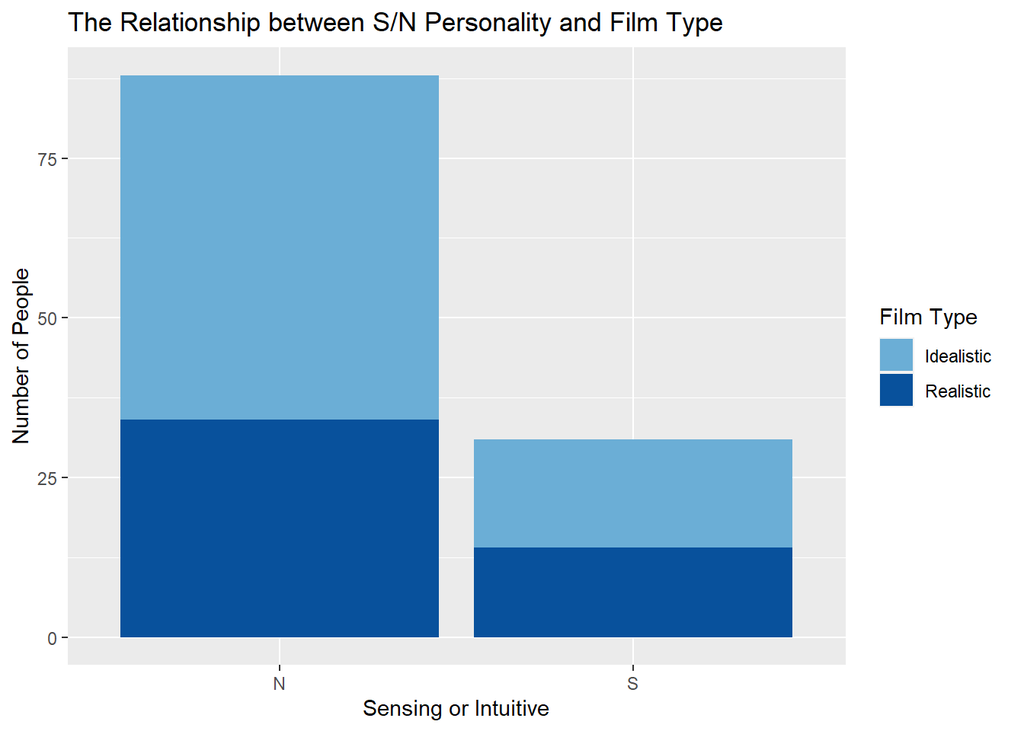

```r
mbti_cleaned <- mbti %>%
mutate(NS = ifelse(str_sub(MBTI, 2,2) %in% c("N", "S"), str_sub(MBTI, 2,2), NA))

ggplot(mbti_cleaned, aes(NS, fill = Type1)) +
 geom_bar(stat="count") +
 labs(x= "Sensing or Intuitive", y = "Number of People", title="The Relationship between S/N Personality and Film Type", fill = "Film Type") +
 scale_fill_manual(values = c("#6BAED6", "#08519C"))
```

The proportion of individuals who enjoy idealistic movies in intuitive types is higher than in sensing types, but the difference is not significant. In both groups, the proportion of individuals who enjoy idealistic films is slightly higher.  
**Film Type**  
Proportion of Detective and Romantic Types

```r
table(mbti$Type2)
```

```
##
## Detective  Romantic
##        82        37
```

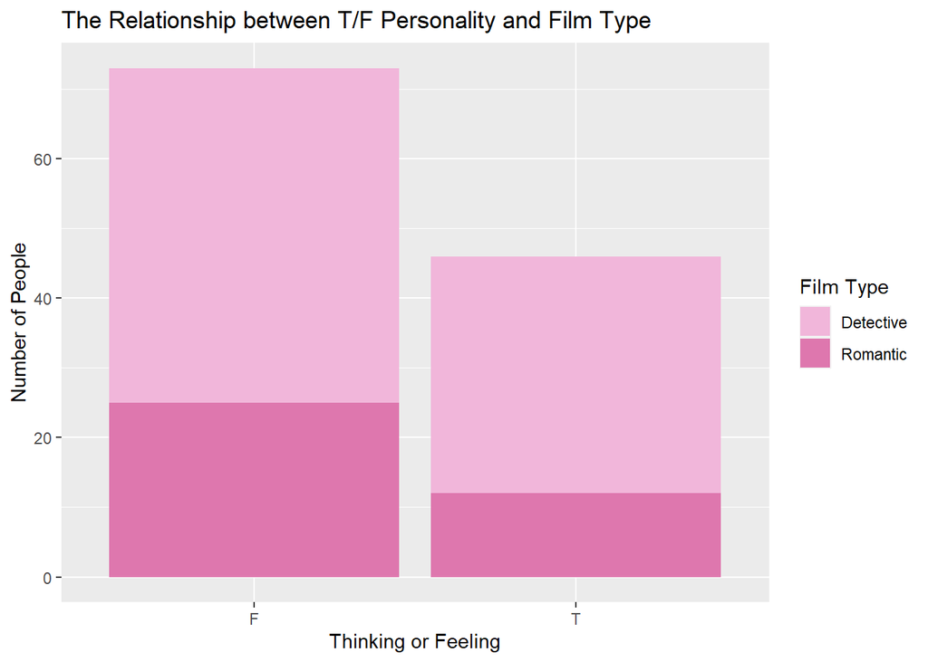

```r
mbti_cleaned <- mbti %>%
mutate(TF = ifelse(str_sub(MBTI, 3,3) %in% c("T", "F"), str_sub(MBTI, 3,3), NA))

ggplot(mbti_cleaned, aes(TF, fill = Type2)) +
 geom_bar(stat="count") +
 labs(x= "Thinking or Feeling", y = "Number of People", title="The Relationship between T/F Personality and Film Type", fill = "Film Type") +
 scale_fill_manual(values = c("#F1B6DA", "#DE77AE"))
```

```r
table(mbti$Pattern)
```

```
##
## Choose a random film based on your mood         Make plans before film watching
##                                      79                                      40
```

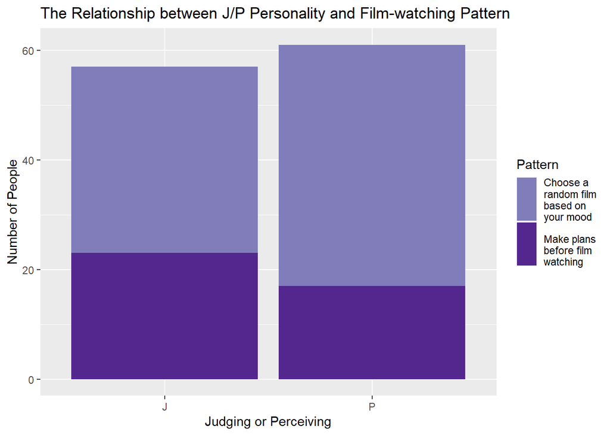

```r
mbti_cleaned <- subset_mbti %>%
 mutate(JP = ifelse(str_sub(MBTI, 4,4) %in% c("J", "P"), str_sub(MBTI, 4,4), NA))


ggplot(mbti_cleaned, aes(JP, fill = Pattern)) +
 geom_bar(stat="count") +
 labs(x="Judging or Perceiving", y="Number of People", fill="Pattern", title="The Relationship between J/P Personality and Film-watching Pattern") +
 scale_fill_manual(values = c("#807DBA", "#54278F"), labels=c('Choose a\nrandom film\nbased on\nyour mood','\nMake plans\nbefore film\nwatching'))
```

## 2.3 Research Question 2

What is the relationship between the preferred row number in cinema and the preferred number of people to watch film with?

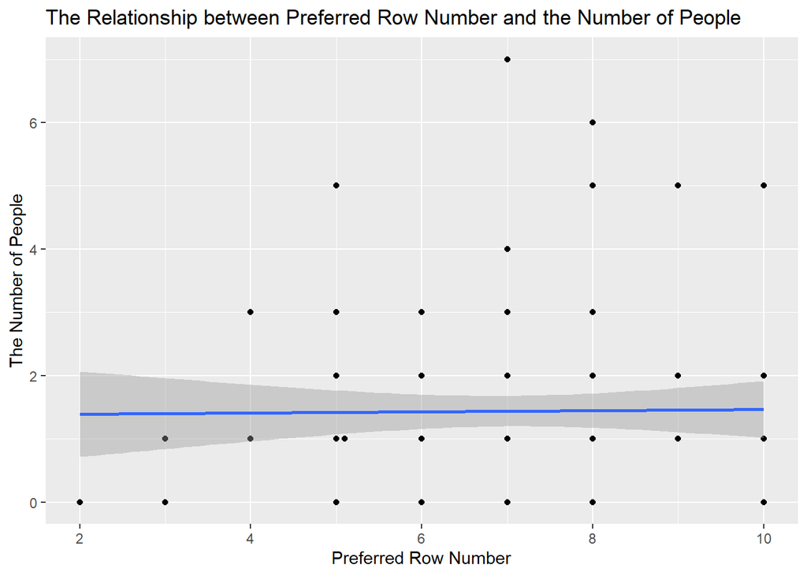

```r
ggplot(mbti, aes(x = Row, y = People)) +
  geom_point() +
  geom_smooth(method = "lm") +
  labs(title="The Relationship between Preferred Row Number and the Number of People") +
  ylab("The Number of People") +
  xlab("Preferred Row Number")
```

```r
cor(mbti$Row, mbti$People)
```

```
## [1] 0.01332238
```

Due to the limited options of the quantitative variables in our research, it’s quite difficult to find two variables with an approxiamately linear relationship. From this scatter plot, the trend line is relatively flat, indicating that there is no significant increase or decrease in the number of people preferring any particular row number.

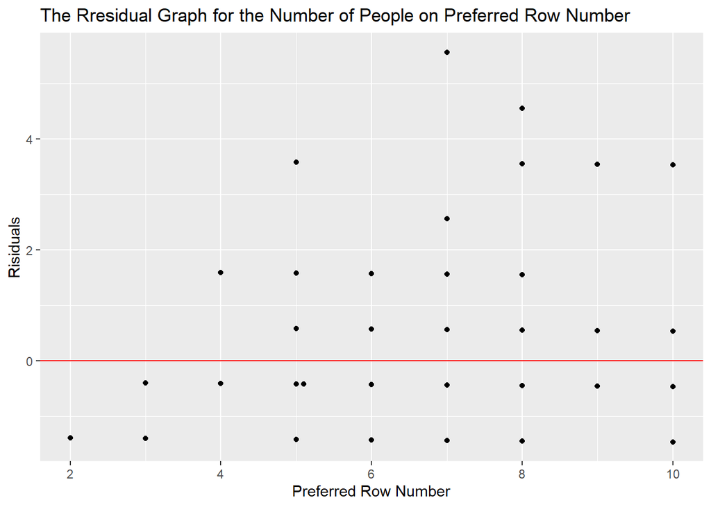

```r
fit = lm(People ~ Row, data = mbti)

ggplot(fit, aes(x = mbti$Row, y = .resid)) +
  geom_point() +
  geom_hline(yintercept = 0, colour = "red") +
  labs(title="The Rresidual Graph for the Number of People on Preferred Row Number") +
  xlab("Preferred Row Number") +
  ylab("Risiduals")
```

The residual plot displays a random scatter of points around the horizontal line at y = 0, indicating that the regression model is not capturing any systematic patterns in the data.

# 3 Articles

The first research reveals the relationship between ways of entertainment and personalities, and the second one explains detailed introduction of each character in 16 personalities based on MBTI. Both of them can provide us ideas in many aspects and prove our results in our data analysis.

**References**  
Style: APA

- Foundation, M. &. B. (2023, July 20). The Preferences: E-I, S-N, T-F, J-P. Myers & Briggs Foundation. https://www.myersbriggs.org/my-mbti-personality-type/the-mbti-preferences/
- Ivo Jirásek, Tereza Janošíková, Filip Sochor, David Češka. (2021). Some specifics of Czech recreation and leisure studies students: Personality types based on MBTI.The Journal of Hospitality, leisure, sport & tourism education, 2021-11, Vol.29, p.100315, Article 100315

# 4 Acknowledgements

**All Resources Used**  
https://www.jianshu.com/p/9384137c49b7 https://blog.csdn.net/qq_18055167/article/details/130295490 https://bookdown.org/wangminjie/R4DS/tidyverse-dplyr.html https://blog.csdn.net/weixin_45822007/article/details/116957309

**Contribution of Each Group Member**  
- YUDU WAN (Leader) | Research Question1, Executive Summary  
- WENYU FAN (Data analyst) | Use Rmarkdown language to write and summarize all modules, IDA-Data Clearing, Research Question 1, Research Question 2  
- ZIHAN NIE (Designer) | IDA-Source, IDA-Structure, IDA-Assumptions, Articles, Acknowledgements  
- WEIHAO ZHANG (Designer) | IDA-Source, IDA-Structure, IDA-Assumptions, Articles, Acknowledgements  
- XIANGYUAN KONG (Data collector) | Research Question 1, Research Question 2，IDA-Limitations  
- JIASEN WANG (Registrar) | IDA-Source, IDA-Structure, IDA-Assumptions, IDA-Data Clearing, Articles, Acknowledgements

**List of Meetings and Contributions**  
9/3/24 meeting | Jiasen Wang, Weihao Zhang, Wenyu Fan, Xiangyuan Kong, Yudu Wan, Zihan Nie | All in Attendance: Development of research theme and variables for Project 1 and Finalisation of Project 1

13/3/24 Lab meeting | Jiasen Wang, Weihao Zhang, Wenyu Fan, Xiangyuan Kong, Yudu Wan, Zihan Nie | All in Attendance: Reviewing the feedback from project 1 and discuss the feasibility of making charts with collected data

26/3/24 Online during afternoon | Jiasen Wang, Weihao Zhang, Wenyu Fan, Xiangyuan Kong, Yudu Wan, Zihan Nie | All in Attendance: Reviewing the feedback from project 1

27/3/24 Lab meeting | Jiasen Wang, Weihao Zhang, Wenyu Fan, Xiangyuan Kong, Yudu Wan, Zihan Nie | All in Attendance: Reviewing the data collected from the survey and performing initial data analysis

10/4/24 Lab meeting | Jiasen Wang, Weihao Zhang, Wenyu Fan, Xiangyuan Kong, Yudu Wan, Zihan Nie | All in Attendance: Certain research questions

12/4/24 Brief Online Discussion | Jiasen Wang, Weihao Zhang, Wenyu Fan, Xiangyuan Kong, Yudu Wan, Zihan Nie | All in Attendance: Use Rstudio to draw and annotate

14/4/24 Discussion in library | Jiasen Wang, Weihao Zhang, Wenyu Fan, Xiangyuan Kong, Yudu Wan, Zihan Nie | All in Attendance: Worked on the script and Article Section

17/4/24 Online Discussion | Jiasen Wang, Weihao Zhang, Wenyu Fan, Xiangyuan Kong, Yudu Wan, Zihan Nie | All in Attendance: Worked on the conclusion and the presentation